# Customer Churn/Turnover Data

## Introduction

Customer churn (a.k.a customer turnover) is the ratio of customers who decide to leave or stop using a company/business's service or product. Various causes can lead to customer churn, such as customer dissatisfaction, better offers from competitors, change in business or personal needs, or lack of engagement. The Customer Churn data set looks at several attributes of customers who decide to end their relationship with a company. This analysis aims to find potential causes of customer turnover and build a decision tree model to predict churn using a decisino tree classifier so that the company can implement actions that can increase customer retention and overall customer loyalty.

**Variable Descriptions**

cust_id: A unique identifier for each customer.

region: The geographic region where the customer resides.

tenure: The number of months or years the customer has been with the company.

age: The age of the customer.

marital: Marital status of the customer (e.g., single, married).

address: The number of months or years the customer has lived at their current address.

income: The customer's income level (likely annual). ed: The education level of the customer (e.g., high school, college).

employ: The number of years the customer has been employed.

retire: Whether the customer is retired

gender: The gender of the customer.

reside: The number of people in the household or how long the customer has lived at the current residence.

tollfree: Whether the customer has a toll-free service.

equip: Whether the customer has equipment provided by the company.

callcard: Whether the customer has a calling card.

wireless: Whether the customer has a wireless service.

longmon: Monthly charges for long-distance service.

tollmon: Monthly charges for toll-free service.

equipmon: Monthly charges for equipment services.

cardmon: Monthly charges for calling card services.

wiremon: Monthly charges for wireless services.

longten: Tenure (in months or years) for long-distance services.

tollten: Tenure (in months or years) for toll-free services.

equipten: Tenure (in months or years) for equipment services.

cardten: Tenure (in months or years) for calling card services.

wireten: Tenure (in months or years) for wireless services.

multline: Whether the customer has multiple phone lines.

voice: Whether the customer has voicemail services.

pager: Whether the customer has a pager service.

internet: Whether the customer has internet services.

callid: Whether the customer has caller ID service.

callwait: Whether the customer has call waiting service.

forward: Whether the customer has call forwarding service.

confer: Whether the customer has conference calling service.

ebill: Whether the customer uses electronic billing.

loglong: The logarithm of the customer's long-distance charges (a transformation used in analysis).

lninc: The logarithm of the customer's income (a transformation used in analysis).

custcat: A categorical variable representing the customer category or segment.

churn: Whether the customer has churned (left the service).

**Target Variable: *churn***

## 1. Data Understanding and Preprocessing

In this step, we loaded the customer churn data set and looked at the sturcture of the data to understand the data. Then, we checked for missing values, inpected the data types, and converted all columns with the 'object' data types into 'category' data types for consistency. The cust_id column was deleted because it was not relevant to the analysis. We also examine basic statistics for numerical and categorical features, from which we created boxplots and barcharts.

### Uploading and Cleaning Data

```python
# Mounting Google Drive
from google.colab import drive
drive.mount('/content/drive')
```

```python
# Import libraries
import pandas as pd
import seaborn as sns
import matplotlib.pyplot as plt
```

```python
#Read Data
churndata = pd.read_csv('/content/drive/MyDrive/IS470_data/CutomerChurnData.csv')
churndata
```

|  | cust_id | region | tenure | age | marital | address | income | ed | employ | retire | ... | internet | callid | callwait | forward | confer | ebill | loglong | lninc | custcat | churn |
| --- | --- | --- | --- | --- | --- | --- | --- | --- | --- | --- | --- | --- | --- | --- | --- | --- | --- | --- | --- | --- | --- |
| 0 | C00124 | R2 | 13 | 44 | Y | 9 | 64 | E4 | 5 | N | ... | N | N | N | Y | N | N | 1.308 | 4.159 | C1 | Y |
| 1 | C00125 | R3 | 68 | 52 | Y | 24 | 116 | E1 | 29 | N | ... | N | Y | Y | N | Y | N | 2.899 | 4.754 | C3 | N |
| 2 | C00126 | R2 | 23 | 30 | Y | 9 | 30 | E1 | 2 | N | ... | N | Y | N | Y | Y | N | 1.841 | 3.401 | C3 | N |
| 3 | C00127 | R3 | 45 | 22 | Y | 2 | 19 | E2 | 4 | N | ... | Y | N | Y | N | N | Y | 2.389 | 2.944 | C2 | Y |
| 4 | C00128 | R3 | 45 | 59 | Y | 7 | 166 | E4 | 31 | N | ... | N | Y | Y | Y | Y | N | 2.277 | 5.112 | C3 | N |
| ... | ... | ... | ... | ... | ... | ... | ... | ... | ... | ... | ... | ... | ... | ... | ... | ... | ... | ... | ... | ... | ... |
| 995 | C01119 | R1 | 50 | 43 | N | 6 | 27 | E3 | 4 | N | ... | N | Y | Y | Y | Y | N | 2.708 | 3.296 | C3 | N |
| 996 | C01120 | R1 | 34 | 52 | Y | 2 | 106 | E2 | 19 | N | ... | Y | Y | N | Y | Y | N | 1.599 | 4.663 | C3 | N |
| 997 | C01121 | R1 | 15 | 46 | Y | 17 | 63 | E5 | 1 | N | ... | Y | Y | N | Y | Y | Y | 1.308 | 4.143 | C4 | Y |
| 998 | C01122 | R1 | 7 | 34 | N | 2 | 22 | E5 | 5 | N | ... | N | N | N | N | N | N | 1.537 | 3.091 | C1 | N |
| 999 | C01123 | R3 | 70 | 49 | N | 18 | 87 | E2 | 22 | N | ... | N | Y | Y | Y | Y | N | 3.243 | 4.466 | C3 | N |

1000 rows × 39 columns

```python
#Examine the number of rows and cols
churndata.shape
```

```
(1000, 39)
```

```python
# Show the head rows of a data frame
churndata.head(3)
```

|  | cust_id | region | tenure | age | marital | address | income | ed | employ | retire | ... | internet | callid | callwait | forward | confer | ebill | loglong | lninc | custcat | churn |
| --- | --- | --- | --- | --- | --- | --- | --- | --- | --- | --- | --- | --- | --- | --- | --- | --- | --- | --- | --- | --- | --- |
| 0 | C00124 | R2 | 13 | 44 | Y | 9 | 64 | E4 | 5 | N | ... | N | N | N | Y | N | N | 1.308 | 4.159 | C1 | Y |
| 1 | C00125 | R3 | 68 | 52 | Y | 24 | 116 | E1 | 29 | N | ... | N | Y | Y | N | Y | N | 2.899 | 4.754 | C3 | N |
| 2 | C00126 | R2 | 23 | 30 | Y | 9 | 30 | E1 | 2 | N | ... | N | Y | N | Y | Y | N | 1.841 | 3.401 | C3 | N |

3 rows × 39 columns

```python
# Show the tail rows of a data frame
churndata.tail()
```

|  | cust_id | region | tenure | age | marital | address | income | ed | employ | retire | ... | internet | callid | callwait | forward | confer | ebill | loglong | lninc | custcat | churn |
| --- | --- | --- | --- | --- | --- | --- | --- | --- | --- | --- | --- | --- | --- | --- | --- | --- | --- | --- | --- | --- | --- |
| 995 | C01119 | R1 | 50 | 43 | N | 6 | 27 | E3 | 4 | N | ... | N | Y | Y | Y | Y | N | 2.708 | 3.296 | C3 | N |
| 996 | C01120 | R1 | 34 | 52 | Y | 2 | 106 | E2 | 19 | N | ... | Y | Y | N | Y | Y | N | 1.599 | 4.663 | C3 | N |
| 997 | C01121 | R1 | 15 | 46 | Y | 17 | 63 | E5 | 1 | N | ... | Y | Y | N | Y | Y | Y | 1.308 | 4.143 | C4 | Y |
| 998 | C01122 | R1 | 7 | 34 | N | 2 | 22 | E5 | 5 | N | ... | N | N | N | N | N | N | 1.537 | 3.091 | C1 | N |
| 999 | C01123 | R3 | 70 | 49 | N | 18 | 87 | E2 | 22 | N | ... | N | Y | Y | Y | Y | N | 3.243 | 4.466 | C3 | N |

5 rows × 39 columns

```python
# Examine missing values
churndata.isnull().sum()
```

|  | 0 |
| --- | --- |
| cust_id | 0 |
| region | 0 |
| tenure | 0 |
| age | 0 |
| marital | 0 |
| address | 0 |
| income | 0 |
| ed | 0 |
| employ | 0 |
| retire | 0 |
| gender | 0 |
| reside | 0 |
| tollfree | 0 |
| equip | 0 |
| callcard | 0 |
| wireless | 0 |
| longmon | 0 |
| tollmon | 0 |
| equipmon | 0 |
| cardmon | 0 |
| wiremon | 0 |
| longten | 0 |
| tollten | 0 |
| equipten | 0 |
| cardten | 0 |
| wireten | 0 |
| multline | 0 |
| voice | 0 |
| pager | 0 |
| internet | 0 |
| callid | 0 |
| callwait | 0 |
| forward | 0 |
| confer | 0 |
| ebill | 0 |
| loglong | 0 |
| lninc | 0 |
| custcat | 0 |
| churn | 0 |

**dtype:** int64

```python
# Remove the unique identifier (cust_id) from further analysis
churndata = churndata.drop(['cust_id'],axis=1)
churndata
```

|  | region | tenure | age | marital | address | income | ed | employ | retire | gender | ... | internet | callid | callwait | forward | confer | ebill | loglong | lninc | custcat | churn |
| --- | --- | --- | --- | --- | --- | --- | --- | --- | --- | --- | --- | --- | --- | --- | --- | --- | --- | --- | --- | --- | --- |
| 0 | R2 | 13 | 44 | Y | 9 | 64 | E4 | 5 | N | N | ... | N | N | N | Y | N | N | 1.308 | 4.159 | C1 | Y |
| 1 | R3 | 68 | 52 | Y | 24 | 116 | E1 | 29 | N | Y | ... | N | Y | Y | N | Y | N | 2.899 | 4.754 | C3 | N |
| 2 | R2 | 23 | 30 | Y | 9 | 30 | E1 | 2 | N | N | ... | N | Y | N | Y | Y | N | 1.841 | 3.401 | C3 | N |
| 3 | R3 | 45 | 22 | Y | 2 | 19 | E2 | 4 | N | Y | ... | Y | N | Y | N | N | Y | 2.389 | 2.944 | C2 | Y |
| 4 | R3 | 45 | 59 | Y | 7 | 166 | E4 | 31 | N | N | ... | N | Y | Y | Y | Y | N | 2.277 | 5.112 | C3 | N |
| ... | ... | ... | ... | ... | ... | ... | ... | ... | ... | ... | ... | ... | ... | ... | ... | ... | ... | ... | ... | ... | ... |
| 995 | R1 | 50 | 43 | N | 6 | 27 | E3 | 4 | N | N | ... | N | Y | Y | Y | Y | N | 2.708 | 3.296 | C3 | N |
| 996 | R1 | 34 | 52 | Y | 2 | 106 | E2 | 19 | N | N | ... | Y | Y | N | Y | Y | N | 1.599 | 4.663 | C3 | N |
| 997 | R1 | 15 | 46 | Y | 17 | 63 | E5 | 1 | N | N | ... | Y | Y | N | Y | Y | Y | 1.308 | 4.143 | C4 | Y |
| 998 | R1 | 7 | 34 | N | 2 | 22 | E5 | 5 | N | Y | ... | N | N | N | N | N | N | 1.537 | 3.091 | C1 | N |
| 999 | R3 | 70 | 49 | N | 18 | 87 | E2 | 22 | N | Y | ... | N | Y | Y | Y | Y | N | 3.243 | 4.466 | C3 | N |

1000 rows × 38 columns

```python
# Examine variable type: int64= number , object= string, bool= T/F
churndata.dtypes
```

|  | 0 |
| --- | --- |
| region | object |
| tenure | int64 |
| age | int64 |
| marital | object |
| address | int64 |
| income | int64 |
| ed | object |
| employ | int64 |
| retire | object |
| gender | object |
| reside | int64 |
| tollfree | object |
| equip | object |
| callcard | object |
| wireless | object |
| longmon | float64 |
| tollmon | float64 |
| equipmon | float64 |
| cardmon | float64 |
| wiremon | float64 |
| longten | float64 |
| tollten | float64 |
| equipten | float64 |
| cardten | int64 |
| wireten | float64 |
| multline | object |
| voice | object |
| pager | object |
| internet | object |
| callid | object |
| callwait | object |
| forward | object |
| confer | object |
| ebill | object |
| loglong | float64 |
| lninc | float64 |
| custcat | object |
| churn | object |

**dtype:** object

```python
# Changecategorical variables to "category"
churndata['region'] = churndata['region'].astype('category')
churndata['marital'] = churndata['marital'].astype('category')
churndata['ed'] = churndata['ed'].astype('category')
churndata['retire'] = churndata['retire'].astype('category')
churndata['gender'] = churndata['gender'].astype('category')
churndata['tollfree'] = churndata['tollfree'].astype('category')
churndata['equip'] = churndata['equip'].astype('category')
churndata['callcard'] = churndata['callcard'].astype('category')
churndata['wireless'] = churndata['wireless'].astype('category')
churndata['multline'] = churndata['multline'].astype('category')
churndata['voice'] = churndata['voice'].astype('category')
churndata['pager'] = churndata['pager'].astype('category')
churndata['internet'] = churndata['internet'].astype('category')
churndata['callid'] = churndata['callid'].astype('category')
churndata['callwait'] = churndata['callwait'].astype('category')
churndata['forward'] = churndata['forward'].astype('category')
churndata['confer'] = churndata['confer'].astype('category')
churndata['ebill'] = churndata['ebill'].astype('category')
churndata['custcat'] = churndata['custcat'].astype('category')
churndata['churn'] = churndata['churn'].astype('category')
churndata.dtypes
```

|  | 0 |
| --- | --- |
| region | category |
| tenure | int64 |
| age | int64 |
| marital | category |
| address | int64 |
| income | int64 |
| ed | category |
| employ | int64 |
| retire | category |
| gender | category |
| reside | int64 |
| tollfree | category |
| equip | category |
| callcard | category |
| wireless | category |
| longmon | float64 |
| tollmon | float64 |
| equipmon | float64 |
| cardmon | float64 |
| wiremon | float64 |
| longten | float64 |
| tollten | float64 |
| equipten | float64 |
| cardten | int64 |
| wireten | float64 |
| multline | category |
| voice | category |
| pager | category |
| internet | category |
| callid | category |
| callwait | category |
| forward | category |
| confer | category |
| ebill | category |
| loglong | float64 |
| lninc | float64 |
| custcat | category |
| churn | category |

**dtype:** object

```python
# Display all numeric variables
churndata.select_dtypes(include=['number'])
```

|  | tenure | age | address | income | employ | reside | longmon | tollmon | equipmon | cardmon | wiremon | longten | tollten | equipten | cardten | wireten | loglong | lninc |
| --- | --- | --- | --- | --- | --- | --- | --- | --- | --- | --- | --- | --- | --- | --- | --- | --- | --- | --- |
| 0 | 13 | 44 | 9 | 64 | 5 | 2 | 3.70 | 0.00 | 0.0 | 7.50 | 0.0 | 37.45 | 0.00 | 0.00 | 110 | 0.0 | 1.308 | 4.159 |
| 1 | 68 | 52 | 24 | 116 | 29 | 2 | 18.15 | 18.00 | 0.0 | 30.25 | 0.0 | 1300.60 | 1247.20 | 0.00 | 2150 | 0.0 | 2.899 | 4.754 |
| 2 | 23 | 30 | 9 | 30 | 2 | 4 | 6.30 | 0.00 | 0.0 | 0.00 | 0.0 | 157.05 | 0.00 | 0.00 | 0 | 0.0 | 1.841 | 3.401 |
| 3 | 45 | 22 | 2 | 19 | 4 | 5 | 10.90 | 0.00 | 0.0 | 8.75 | 0.0 | 504.50 | 0.00 | 0.00 | 415 | 0.0 | 2.389 | 2.944 |
| 4 | 45 | 59 | 7 | 166 | 31 | 5 | 9.75 | 28.50 | 0.0 | 12.00 | 0.0 | 449.05 | 1240.15 | 0.00 | 505 | 0.0 | 2.277 | 5.112 |
| ... | ... | ... | ... | ... | ... | ... | ... | ... | ... | ... | ... | ... | ... | ... | ... | ... | ... | ... |
| 995 | 50 | 43 | 6 | 27 | 4 | 1 | 15.00 | 45.25 | 0.0 | 52.75 | 0.0 | 817.85 | 2320.25 | 0.00 | 2645 | 0.0 | 2.708 | 3.296 |
| 996 | 34 | 52 | 2 | 106 | 19 | 2 | 4.95 | 19.00 | 0.0 | 13.50 | 0.0 | 153.50 | 649.35 | 0.00 | 430 | 0.0 | 1.599 | 4.663 |
| 997 | 15 | 46 | 17 | 63 | 1 | 2 | 3.70 | 16.50 | 42.5 | 0.00 | 33.1 | 40.55 | 207.35 | 547.95 | 0 | 475.3 | 1.308 | 4.143 |
| 998 | 7 | 34 | 2 | 22 | 5 | 1 | 4.65 | 0.00 | 25.6 | 0.00 | 0.0 | 29.35 | 0.00 | 179.10 | 0 | 0.0 | 1.537 | 3.091 |
| 999 | 70 | 49 | 18 | 87 | 22 | 1 | 25.60 | 33.50 | 0.0 | 25.25 | 0.0 | 1841.85 | 2368.20 | 0.00 | 1705 | 0.0 | 3.243 | 4.466 |

1000 rows × 18 columns

```python
# Display all categorical variables
churndata.select_dtypes(include=['category'])
```

|  | region | marital | ed | retire | gender | tollfree | equip | callcard | wireless | multline | voice | pager | internet | callid | callwait | forward | confer | ebill | custcat | churn |
| --- | --- | --- | --- | --- | --- | --- | --- | --- | --- | --- | --- | --- | --- | --- | --- | --- | --- | --- | --- | --- |
| 0 | R2 | Y | E4 | N | N | N | N | Y | N | N | N | N | N | N | N | Y | N | N | C1 | Y |
| 1 | R3 | Y | E1 | N | Y | Y | N | Y | N | N | N | N | N | Y | Y | N | Y | N | C3 | N |
| 2 | R2 | Y | E1 | N | N | N | N | N | N | N | N | N | N | Y | N | Y | Y | N | C3 | N |
| 3 | R3 | Y | E2 | N | Y | N | N | Y | N | Y | N | N | Y | N | Y | N | N | Y | C2 | Y |
| 4 | R3 | Y | E4 | N | N | Y | N | Y | N | Y | N | N | N | Y | Y | Y | Y | N | C3 | N |
| ... | ... | ... | ... | ... | ... | ... | ... | ... | ... | ... | ... | ... | ... | ... | ... | ... | ... | ... | ... | ... |
| 995 | R1 | N | E3 | N | N | Y | N | Y | N | N | N | N | N | Y | Y | Y | Y | N | C3 | N |
| 996 | R1 | Y | E2 | N | N | Y | N | Y | N | N | N | N | Y | Y | N | Y | Y | N | C3 | N |
| 997 | R1 | Y | E5 | N | N | Y | Y | N | Y | Y | Y | Y | Y | Y | N | Y | Y | Y | C4 | Y |
| 998 | R1 | N | E5 | N | Y | N | Y | N | N | N | N | N | N | N | N | N | N | N | C1 | N |
| 999 | R3 | N | E2 | N | Y | Y | N | Y | N | N | Y | N | N | Y | Y | Y | Y | N | C3 | N |

1000 rows × 20 columns

### Understanding and Visualizing Data

```python
#Get summary statistics for all numerical data
churndata.describe()
```

|  | tenure | age | address | income | employ | reside | longmon | tollmon | equipmon | cardmon | wiremon | longten | tollten | equipten | cardten | wireten | loglong | lninc |
| --- | --- | --- | --- | --- | --- | --- | --- | --- | --- | --- | --- | --- | --- | --- | --- | --- | --- | --- |
| count | 1000.000000 | 1000.000000 | 1000.000000 | 1000.000000 | 1000.00000 | 1000.000000 | 1000.000000 | 1000.00000 | 1000.000000 | 1000.000000 | 1000.00000 | 1000.000000 | 1000.000000 | 1000.000000 | 1000.000000 | 1000.000000 | 1000.000000 | 1000.000000 |
| mean | 35.242000 | 41.552000 | 11.576000 | 71.906000 | 10.79000 | 2.316000 | 11.163600 | 13.34350 | 13.572200 | 13.911500 | 10.88070 | 536.994100 | 535.407900 | 440.293200 | 616.090000 | 423.188500 | 2.149468 | 3.926546 |
| std | 21.295937 | 12.679435 | 10.132467 | 80.297826 | 10.14499 | 1.434644 | 9.540451 | 17.41479 | 18.850834 | 14.404653 | 19.24529 | 729.764065 | 867.466796 | 848.250381 | 874.929462 | 961.485455 | 0.716255 | 0.778627 |
| min | 1.000000 | 18.000000 | 0.000000 | 9.000000 | 0.00000 | 1.000000 | 1.050000 | 0.00000 | 0.000000 | 0.000000 | 0.00000 | 1.050000 | 0.000000 | 0.000000 | 0.000000 | 0.000000 | 0.049000 | 2.197000 |
| 25% | 16.000000 | 32.000000 | 3.750000 | 28.000000 | 3.00000 | 1.000000 | 5.150000 | 0.00000 | 0.000000 | 0.000000 | 0.00000 | 86.037500 | 0.000000 | 0.000000 | 0.000000 | 0.000000 | 1.639000 | 3.332000 |
| 50% | 34.500000 | 40.000000 | 9.000000 | 46.000000 | 8.00000 | 2.000000 | 8.500000 | 0.00000 | 0.000000 | 12.125000 | 0.00000 | 288.225000 | 0.000000 | 0.000000 | 362.500000 | 0.000000 | 2.140000 | 3.829000 |
| 75% | 53.000000 | 51.000000 | 18.000000 | 83.250000 | 17.25000 | 3.000000 | 13.862500 | 24.25000 | 30.787500 | 19.562500 | 23.58750 | 700.387500 | 836.912500 | 466.512500 | 871.250000 | 140.075000 | 2.629000 | 4.422000 |
| max | 72.000000 | 77.000000 | 55.000000 | 732.000000 | 47.00000 | 7.000000 | 99.950000 | 173.00000 | 77.700000 | 109.250000 | 109.70000 | 7257.600000 | 4905.850000 | 4758.050000 | 7515.000000 | 6444.950000 | 4.605000 | 6.596000 |

```python
#Get summary statistics for tenure, income, age
churndata[['tenure','income','age']].describe()
```

|  | tenure | income | age |
| --- | --- | --- | --- |
| count | 1000.000000 | 1000.000000 | 1000.000000 |
| mean | 35.242000 | 71.906000 | 41.552000 |
| std | 21.295937 | 80.297826 | 12.679435 |
| min | 1.000000 | 9.000000 | 18.000000 |
| 25% | 16.000000 | 28.000000 | 32.000000 |
| 50% | 34.500000 | 46.000000 | 40.000000 |
| 75% | 53.000000 | 83.250000 | 51.000000 |
| max | 72.000000 | 732.000000 | 77.000000 |

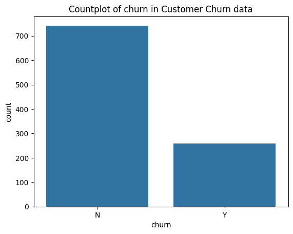

```python
#Countplot of categorical variable:churn
snsplot = sns.countplot(x='churn', data = churndata)
snsplot.set_title("Countplot of churn in Customer Churn data")
```

```python
# Obtain the variance, standard deviation, and range of Income
print("Income variance: ",churndata['income'].var(),"standard deviation:", churndata['income'].std(),"range: ", churndata['income'].max()-churndata['income'].min())
```

```
Income variance:  6447.740904904906 standard deviation: 80.29782627758304 range:  723
```

```python
#Display IQR of Income
IQR = churndata['income'].quantile(0.75)- churndata['income'].quantile(0.25)
print("Income IQR: ", IQR)
```

```
Income IQR:  55.25
```

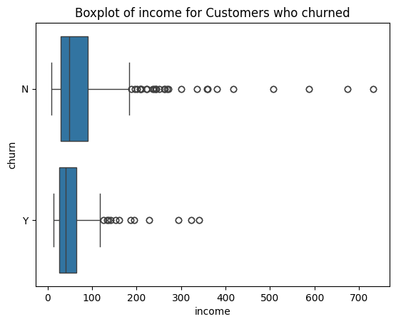

```python
#BoxPlot of numeric variable: income and churn
snsplot = sns.boxplot(y='churn', x='income', data = churndata)
snsplot.set_title("Boxplot of income for Customers who churned")
```

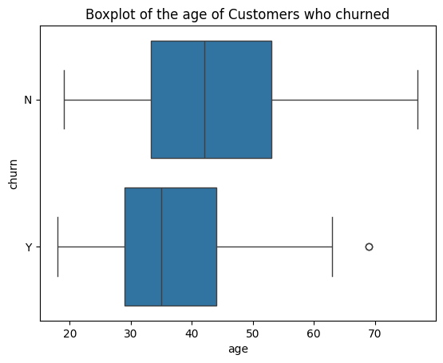

```python
#Boxplot of numeric variable: age and churn
snsplot = sns.boxplot(x='age', y = 'churn', data = churndata)
snsplot.set_title("Boxplot of the age of Customers who churned")
```

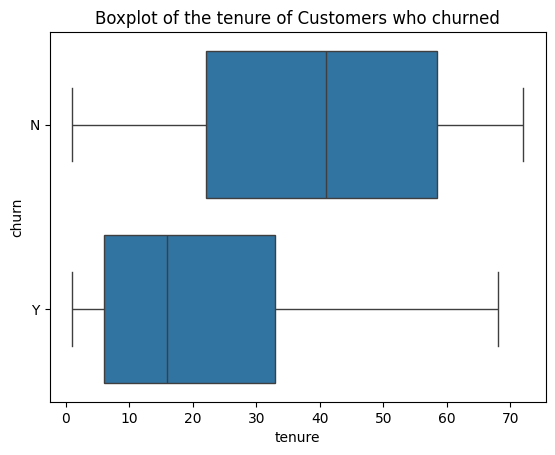

```python
#Boxplot of numeric variable: tenure and churn
snsplot = sns.boxplot(x='tenure',y= 'churn', data = churndata)
snsplot.set_title("Boxplot of the tenure of Customers who churned")
```

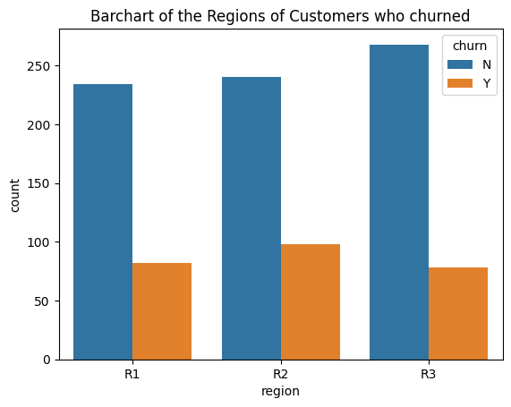

```python
#Barchart of the Regions of Customers who churned
snsplot = sns.countplot(x='region', hue ='churn', data = churndata)
snsplot.set_title("Barchart of the Regions of Customers who churned")
```

In the Customer Churn dataset, there were no missing values, and contains numerical and categorical features. The charts included show the relationship between income/age/tenure/region and churn. Income dataset is right-skewed with many outliers, however the comparasion between the customers who stopped using the service and who continued shows that lower income resulted in a increase of turnover. Age and tenure boxplots show that customers from ages 30 to 40 and customers with less tenure ranging from 10 to 30 have a higher turnover rate. Region R2 has a slightly higher turnover rate than R1 and R3, despite R3 having more customers. **Overall, the data is not balanced.** More customers in this dataset have not stopped using the service.

## Model Development

To train and develope the decision tree model, we will balance the dataset and split it into training and testing dets. The training model will be used to build the decision tree, and the test set will be used for evaluation.

```python
# Import libraries
import pandas as pd
from sklearn.model_selection import train_test_split
from matplotlib import pyplot as plt
from sklearn import tree
from sklearn.tree import DecisionTreeClassifier
from sklearn.metrics import confusion_matrix
from sklearn.metrics import ConfusionMatrixDisplay
from sklearn.metrics import classification_report
```

```python
churndata.keys()
```

```
Index(['region', 'tenure', 'age', 'marital', 'address', 'income', 'ed',
       'employ', 'retire', 'gender', 'reside', 'tollfree', 'equip', 'callcard',
       'wireless', 'longmon', 'tollmon', 'equipmon', 'cardmon', 'wiremon',
       'longten', 'tollten', 'equipten', 'cardten', 'wireten', 'multline',
       'voice', 'pager', 'internet', 'callid', 'callwait', 'forward', 'confer',
       'ebill', 'loglong', 'lninc', 'custcat', 'churn'],
      dtype='object')
```

```python
# Select the desired columns only
desired_columns = ['tenure', 'age', 'region', 'income', 'internet','tollfree','wireless',
'equip', 'multline','pager','voice', 'longmon', 'tollmon', 'equipmon', 'cardmon','wiremon','churn','custcat']
churn_desired = churndata[desired_columns]
```

```python
# Replacing 1 with Yes and 0 with No in the target column 'churn'
churndata = churn_desired.copy()
churndata.loc[:, 'churn'] = churndata['churn'].replace({0: 'No', 1: 'Yes'})
```

```python
# Create dummy variables
churndata = pd.get_dummies(churndata, columns=['region', 'internet', 'tollfree','equip','wireless','multline','voice','pager','custcat'], drop_first=True)
churndata
```

|  | tenure | age | income | longmon | tollmon | equipmon | cardmon | wiremon | churn | region_R2 | ... | internet_Y | tollfree_Y | equip_Y | wireless_Y | multline_Y | voice_Y | pager_Y | custcat_C2 | custcat_C3 | custcat_C4 |
| --- | --- | --- | --- | --- | --- | --- | --- | --- | --- | --- | --- | --- | --- | --- | --- | --- | --- | --- | --- | --- | --- |
| 0 | 13 | 44 | 64 | 3.70 | 0.00 | 0.0 | 7.50 | 0.0 | Y | True | ... | False | False | False | False | False | False | False | False | False | False |
| 1 | 68 | 52 | 116 | 18.15 | 18.00 | 0.0 | 30.25 | 0.0 | N | False | ... | False | True | False | False | False | False | False | False | True | False |
| 2 | 23 | 30 | 30 | 6.30 | 0.00 | 0.0 | 0.00 | 0.0 | N | True | ... | False | False | False | False | False | False | False | False | True | False |
| 3 | 45 | 22 | 19 | 10.90 | 0.00 | 0.0 | 8.75 | 0.0 | Y | False | ... | True | False | False | False | True | False | False | True | False | False |
| 4 | 45 | 59 | 166 | 9.75 | 28.50 | 0.0 | 12.00 | 0.0 | N | False | ... | False | True | False | False | True | False | False | False | True | False |
| ... | ... | ... | ... | ... | ... | ... | ... | ... | ... | ... | ... | ... | ... | ... | ... | ... | ... | ... | ... | ... | ... |
| 995 | 50 | 43 | 27 | 15.00 | 45.25 | 0.0 | 52.75 | 0.0 | N | False | ... | False | True | False | False | False | False | False | False | True | False |
| 996 | 34 | 52 | 106 | 4.95 | 19.00 | 0.0 | 13.50 | 0.0 | N | False | ... | True | True | False | False | False | False | False | False | True | False |
| 997 | 15 | 46 | 63 | 3.70 | 16.50 | 42.5 | 0.00 | 33.1 | Y | False | ... | True | True | True | True | True | True | True | False | False | True |
| 998 | 7 | 34 | 22 | 4.65 | 0.00 | 25.6 | 0.00 | 0.0 | N | False | ... | False | False | True | False | False | False | False | False | False | False |
| 999 | 70 | 49 | 87 | 25.60 | 33.50 | 0.0 | 25.25 | 0.0 | N | False | ... | False | True | False | False | False | True | False | False | True | False |

1000 rows × 21 columns

```python
# Examine the porportion of target variable for data set
target = churndata['churn']
print(target.value_counts(normalize=True))
```

```
churn
N    0.742
Y    0.258
Name: proportion, dtype: float64
```

```python
# Partition the data
predictors = churndata.drop(['churn'],axis=1)
predictors_train, predictors_test, target_train, target_test = train_test_split(predictors, target, test_size=0.3, random_state=0)
print(predictors_train.shape, predictors_test.shape, target_train.shape, target_test.shape)
```

```
(700, 20) (300, 20) (700,) (300,)
```

```python
target_test.head()
```

|  | churn |
| --- | --- |
| 993 | Y |
| 859 | N |
| 298 | N |
| 553 | N |
| 672 | N |

**dtype:** category

```python
target_train.head()
```

|  | churn |
| --- | --- |
| 105 | N |
| 68 | N |
| 479 | N |
| 399 | N |
| 434 | N |

**dtype:** category

```python
predictors_test.head()
```

|  | tenure | age | income | longmon | tollmon | equipmon | cardmon | wiremon | region_R2 | region_R3 | internet_Y | tollfree_Y | equip_Y | wireless_Y | multline_Y | voice_Y | pager_Y | custcat_C2 | custcat_C3 | custcat_C4 |
| --- | --- | --- | --- | --- | --- | --- | --- | --- | --- | --- | --- | --- | --- | --- | --- | --- | --- | --- | --- | --- |
| 993 | 3 | 26 | 59 | 2.55 | 23.50 | 29.6 | 10.75 | 19.2 | True | False | False | True | True | True | False | True | True | False | False | True |
| 859 | 60 | 53 | 93 | 13.35 | 39.50 | 0.0 | 21.00 | 0.0 | False | False | False | True | False | False | False | False | False | False | True | False |
| 298 | 19 | 26 | 48 | 7.55 | 0.00 | 0.0 | 6.50 | 0.0 | True | False | False | False | False | False | False | True | False | False | True | False |
| 553 | 35 | 61 | 41 | 9.60 | 0.00 | 0.0 | 9.50 | 0.0 | False | False | False | False | False | False | False | False | False | False | False | False |
| 672 | 56 | 44 | 87 | 14.75 | 42.25 | 0.0 | 16.25 | 0.0 | True | False | False | True | False | False | False | False | False | False | True | False |

```python
predictors_train.head()
```

|  | tenure | age | income | longmon | tollmon | equipmon | cardmon | wiremon | region_R2 | region_R3 | internet_Y | tollfree_Y | equip_Y | wireless_Y | multline_Y | voice_Y | pager_Y | custcat_C2 | custcat_C3 | custcat_C4 |
| --- | --- | --- | --- | --- | --- | --- | --- | --- | --- | --- | --- | --- | --- | --- | --- | --- | --- | --- | --- | --- |
| 105 | 13 | 55 | 250 | 4.10 | 0.0 | 0.0 | 0.00 | 0.00 | False | True | False | False | False | False | False | False | False | False | False | False |
| 68 | 40 | 38 | 96 | 9.30 | 0.0 | 0.0 | 0.00 | 0.00 | True | False | False | False | False | False | False | False | False | False | False | False |
| 479 | 46 | 55 | 269 | 10.10 | 39.0 | 0.0 | 18.00 | 0.00 | True | False | False | True | False | False | False | False | True | False | True | False |
| 399 | 72 | 45 | 98 | 30.25 | 0.0 | 0.0 | 13.25 | 42.85 | True | False | False | False | False | True | True | True | True | False | False | True |
| 434 | 24 | 31 | 41 | 8.50 | 20.0 | 0.0 | 13.00 | 0.00 | True | False | False | True | False | False | False | False | False | False | True | False |

```python
print(combined_train_df['churn'].value_counts())
```

[output not shown]

```python
# Taking steps to balance the train data
# Combine predictors_train and target_train into a single DataFrame
combined_train_df = pd.concat([predictors_train, target_train], axis=1)

# Separate majority and minority classes
# Separate majority and minority classes based on the correct labels
majority_df = combined_train_df[combined_train_df['churn'] == 'N']
minority_df = combined_train_df[combined_train_df['churn'] == 'Y']


# Undersample the majority class randomly
undersampled_majority = majority_df.sample(n=len(minority_df), random_state=5)

# Combine the undersampled majority class and the minority class
undersampled_data = pd.concat([undersampled_majority, minority_df])

# Shuffle the combined DataFrame to ensure randomness
balanced_data = undersampled_data.sample(frac=1, random_state=5)

# Split the balanced_data into predictors_train and target_train
predictors_train = balanced_data.drop(columns=['churn'])
target_train = balanced_data['churn']
```

```python
combined_train_df['churn'] == 'Y'
```

|  | churn |
| --- | --- |
| 105 | False |
| 68 | False |
| 479 | False |
| 399 | False |
| 434 | False |
| ... | ... |
| 835 | False |
| 192 | False |
| 629 | False |
| 559 | False |
| 684 | False |

700 rows × 1 columns

**dtype:** bool

```python
# Examine the porportion of target variable for train set
print(target_train.value_counts(normalize=True), target_train.shape)
```

```
churn
N    0.5
Y    0.5
Name: proportion, dtype: float64 (342,)
```

```python
# Examine the porportion of target variable for train set
print(target_test.value_counts(normalize=True))
```

```
churn
N    0.71
Y    0.29
Name: proportion, dtype: float64
```

```python
predictors_train.head()
```

|  | tenure | age | income | longmon | tollmon | equipmon | cardmon | wiremon | region_R2 | region_R3 | internet_Y | tollfree_Y | equip_Y | wireless_Y | multline_Y | voice_Y | pager_Y | custcat_C2 | custcat_C3 | custcat_C4 |
| --- | --- | --- | --- | --- | --- | --- | --- | --- | --- | --- | --- | --- | --- | --- | --- | --- | --- | --- | --- | --- |
| 187 | 7 | 43 | 69 | 4.45 | 0.00 | 0.0 | 0.00 | 0.0 | True | False | False | False | False | False | False | False | False | False | False | False |
| 719 | 48 | 35 | 50 | 12.85 | 21.75 | 0.0 | 17.00 | 0.0 | True | False | False | True | False | False | False | True | False | False | True | False |
| 657 | 17 | 68 | 335 | 3.55 | 18.75 | 0.0 | 29.25 | 27.9 | True | False | False | True | False | True | False | True | True | False | False | True |
| 248 | 18 | 31 | 24 | 12.15 | 0.00 | 0.0 | 0.00 | 0.0 | False | True | False | False | False | False | True | False | False | True | False | False |
| 914 | 23 | 25 | 28 | 4.15 | 0.00 | 0.0 | 0.00 | 0.0 | False | True | False | False | False | False | True | False | False | True | False | False |

### Results and Model Evaluation

The decision tree classifier will be developed using the training data from the previous step. The decision tree will help predict whether a customer will churn based on their attributes- internet, tenure, longmon, age, income, and cardmon.

```python
# Build a decision tree model on training data with max_depth = 3
model_DT = DecisionTreeClassifier(criterion = "entropy", random_state = 1, max_depth = 3)
model_DT.fit(predictors_train, target_train)
```

```
DecisionTreeClassifier(criterion='entropy', max_depth=3, random_state=1)
```

```python
predictors_train.columns
```

```
Index(['tenure', 'age', 'income', 'longmon', 'tollmon', 'equipmon', 'cardmon',
       'wiremon', 'region_R2', 'region_R3', 'internet_Y', 'tollfree_Y',
       'equip_Y', 'wireless_Y', 'multline_Y', 'voice_Y', 'pager_Y',
       'custcat_C2', 'custcat_C3', 'custcat_C4'],
      dtype='object')
```

[output not shown]

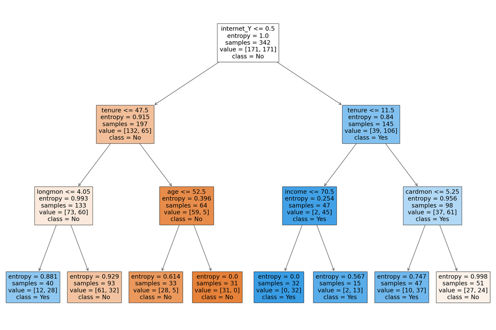

```python
# Plot the tree (0.5 pts)
fig = plt.figure(figsize=(30,20))
tree.plot_tree(model_DT,
               feature_names=list(predictors_train.columns),
               class_names=['No','Yes'],
               filled=True)
```

```python
# Text version of decision tree
print(tree.export_text(model_DT, feature_names=list(churndata.columns)[1:]))
```

```
|--- internet_Y <= 0.50
|   |--- age <= 47.50
|   |   |--- tollmon <= 4.05
|   |   |   |--- class: Y
|   |   |--- tollmon >  4.05
|   |   |   |--- class: N
|   |--- age >  47.50
|   |   |--- income <= 52.50
|   |   |   |--- class: N
|   |   |--- income >  52.50
|   |   |   |--- class: N
|--- internet_Y >  0.50
|   |--- age <= 11.50
|   |   |--- longmon <= 70.50
|   |   |   |--- class: Y
|   |   |--- longmon >  70.50
|   |   |   |--- class: Y
|   |--- age >  11.50
|   |   |--- wiremon <= 5.25
|   |   |   |--- class: Y
|   |   |--- wiremon >  5.25
|   |   |   |--- class: N
```

```python
# Make predictions on testing data
prediction_on_test_DT = model_DT.predict(predictors_test)
```

[output not shown]

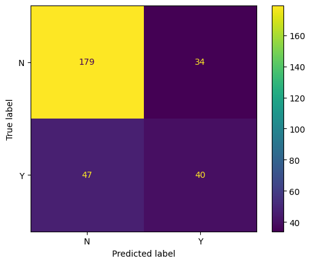

```python
# Examine the evaluation results on testing data: confusion_matrix
cm_DT = confusion_matrix(target_test, prediction_on_test_DT)
ConfusionMatrixDisplay(confusion_matrix=cm_DT, display_labels=model_DT.classes_).plot()
```

```python
# Examine the evaluation results on testing data: accuracy, precision, recall, and f1-score
print(classification_report(target_test, prediction_on_test_DT))
```

```
              precision    recall  f1-score   support

           N       0.79      0.84      0.82       213
           Y       0.54      0.46      0.50        87

    accuracy                           0.73       300
   macro avg       0.67      0.65      0.66       300
weighted avg       0.72      0.73      0.72       300
```

## Conclusion

In this report, we built a decision tree model that can potentially predict customer churn. The data understanding, and preprocessing stage, we were able to see the imbalance of the data, outliers, and inital visualizations of potential predictors of churn through barcharts and boxplots. The Model development stage, we were able to balance the data to get a more stable decision tree model. **The decision tree model is good at detecting if a customer is not going to be a churner (precision 'N': 0.79, f1-score 'N': 0.82), however it only detects half of the 'Yes' cases accurately (precision 'Y' : 0.54, f1-score 'Y':0.5)**. The predictors used in this model were: tenure,age, income, longmon, tollmon, equipmon cardmon wiremon region_R2 region_R3, internet_Y, tollfree_Y, equip_Y, wireless_Y, multline_Y, voice_Y, pager_Y, custcat_C2, custcat_C3,custcat_C4. The decision nodes of the tree are internet, tenure, longmon, age, income, and cardmon. **If a customer buys interent service ('internet') and how long a customer has had the service (tenure) are the variables with the highest impact on the prediction.** A more complex tree may be able to give a more accurate assessment of customers who will churn.